# An Investigation of the Covid-19-related Fake News Sharing on Facebook Using a Mixed Methods Approach

Cristiane Melchior, Thierry Warin, and Mírian Oliveira

2025-01-12

This webpage is a companion website that holds extra resources as part of the article entitled: “An Investigation of the Covid-19-related Fake News Sharing on Facebook Using a Mixed Methods Approach”, authored by Cristiane Melchior, Thierry Warin, and Mírian Oliveira, published on Technological Forecasting & Social Change.

## Literature Review

The table presented in the Literature Review section of the main manuscript of the article summarizes the constructs, themes, theories, and methods used on each of the listed works. Here, we present extra information regarding the data collection and analyses used in each of the related works.

| Work | Data collection Method | Data collection Source | Data collection Place | Data analysis Method | Data analysis Software |
| --- | --- | --- | --- | --- | --- |
| (Marett and Joshi 2009) | Survey with 471 participants from an open online forum | Snowball | United States | SEM | AMOS |
| (Hart and Nisbet 2012) | Experiment with 240 participants | In person | New York | OLS regression | - |
| (Chua and Banerjee 2018) | Survey with 60 medical professionals | In person in a public hospital | Asia | Hierarchical regression and experiment design | - |
| (Ku et al. 2019) | Survey with 1,505 adolescents | In person | Hong Kong, China | Multivariate analysis (MANOVA) and hierarchical regression | - |
| (Khan and Idris 2019) | Survey with 396 participants | Snowball | Indonesia | Regression | SPSS |
| (Kim, Moravec, and Dennis 2019) | Survey and experiment with 590 participants | In person | United States | Regression | Stata |
| (Kim and Dennis 2019) | Survey and experiment with 445 participants | In person | United States | Regression | Stata |
| (Moravec, Minas, and Dennis 2019) | Experiment with 83 Facebook users | In person | United States | Electroencephalography (EEG) | Stata |
| (Moravec, Kim, and Dennis 2020) | Survey with 398 participants | MTurk | United States | Regression | Stata |
| (Talwar et al. 2019) | Open-ended essay with 88 WhatsApp users | In person | Northern India | - | NVIVO |
|  | Survey with 1,022 WhatsApp users | In person in three universities | Lahore, Pakistan | SEM | SPSS and AMOS |
| (Talwar et al. 2020) | Open-ended essay with 58 WhatsApp users | - | - | - | NVIVO |
|  | Survey with 471 WhatsApp users | In person | Northern India | SEM | SPSS and AMOS |
|  | Survey with 374 WhatsApp users | In person | Western India | SEM | SPSS and AMOS |
| (Islam et al. 2020) | Survey with 433 participants | Weboprol, Facebook, and a private university | Bangladesh | PLS-SEM and neural network | SmartPLS and SPSS |
| (Ardèvol-Abreu, Delponti, and Rodríguez-Wangüemert 2020) | Survey with 471 participants | Snowball | Spain | OLS regression | - |
|  | Focus group with 31 participants | In person | Spain | OLS regression | - |
| (De Simoni et al. 2020) | Interview with 17 participants | SurveyMonkey | United Kingdom | Inductive content analysis | - |
| (Pennycook, McPhetres, et al. 2020) | Survey with 853 Facebook or Twitter users | Lucid | United States | Regression | - |
|  | Survey with 856 Facebook or Twitter users | Lucid | United States | Regression | - |
| (Pennycook, Bear, et al. 2020) | Survey and experiment with 5,271 participants | MTurk | United States | Bayesian model and regression | - |
|  | Survey and experiment with 1,568 participants | MTurk | United States | Bayesian model and regression | - |
| (Pennycook et al. 2021) | Survey 1 with 1,005 participants | MTurk | United States | Regression | - |
|  | Survey 2 with 401 participants | Lucid | United States | Regression | - |
|  | Survey 3 with 727 participants | MTurk | United States | Regression | - |
|  | Survey 4 with 780 participants | MTurk | United States | Regression | - |
|  | Survey 5 with 671 participants | Lucid | United States | Regression | - |
|  | Survey 6 with 398 participants | MTurk | United States | Regression | - |
|  | Digital field experiment with 5,379 participants | Twitter | United States | Regression | - |
| (Mahamad et al. 2021) | Interview with 15 participants | In person or online | Selangor, Malaysia | - | NVivo |
| (Apuke and Omar 2021a) | Survey with 385 participants | Snowball | Nigeria | PLS-SEM | SmartPLS |
| (Apuke and Omar 2021b) | Survey with 152 Facebook and WhatsApp users | Snowball | Nigeria | PLS-SEM | SmartPLS |
| (Atehortua and Patino 2021) | Content analysis of 342 fake news messages | Snowball | World | Krippendorff’s (KALPHA) nominal binary alpha | SPSS |
| (Sampat and Raj 2022) | Survey with 221 social media users | Snowball | India | PLS-SEM | - |
| (Shahid, Mare, and Vashistha 2022) | Survey with 319 urban participants | MTurk | India | Regression | - |
|  | Survey with 159 rural participants | Snowball | Uttar Pradesh, India | Regression | - |
| (Hossain et al. 2023) | Survey with 185 participants | Direct recruitment from retail supply chain members | Australia | PLS-SEM and fsQCA | SmartPLS and fsQCA |
| This study | Survey with 338 participants | Snowball | World | SEM and fsQCA | R, SmartPLS, and fsQCA |

## Respondents’ demographics

When we analyze the education and gender of respondents, we can observe that women represent the majority of the respondents in all the education level categories, with the only exception of respondents holding a master’s degree, where there were 37 (11%) men and 35 (10%) women. Regarding the age and gender of the participants surveyed, most respondents are female Facebook users aged between 25 and 34 years old.

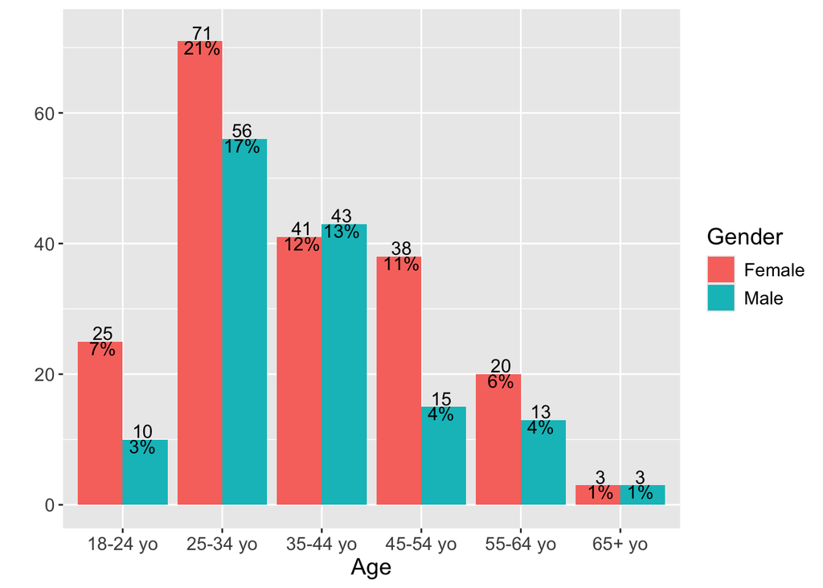

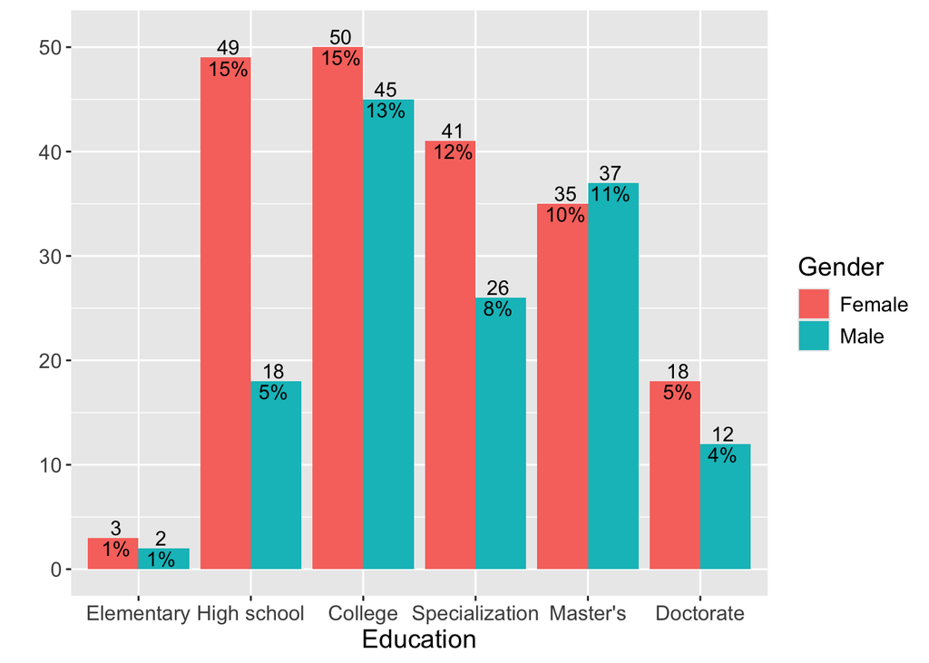

Age, gender, and education of respondents

The following plot presents the professional activity of the respondents by gender. The are many respondents on the educational sector, mostly women, which reflects the fact that the sample was collected through snowballing in the researcher’s social networks. It worth noting that students were also classified in this sector. However, these represent only 18% of the total sample, thus we were able to collect answers from a very diverse public.

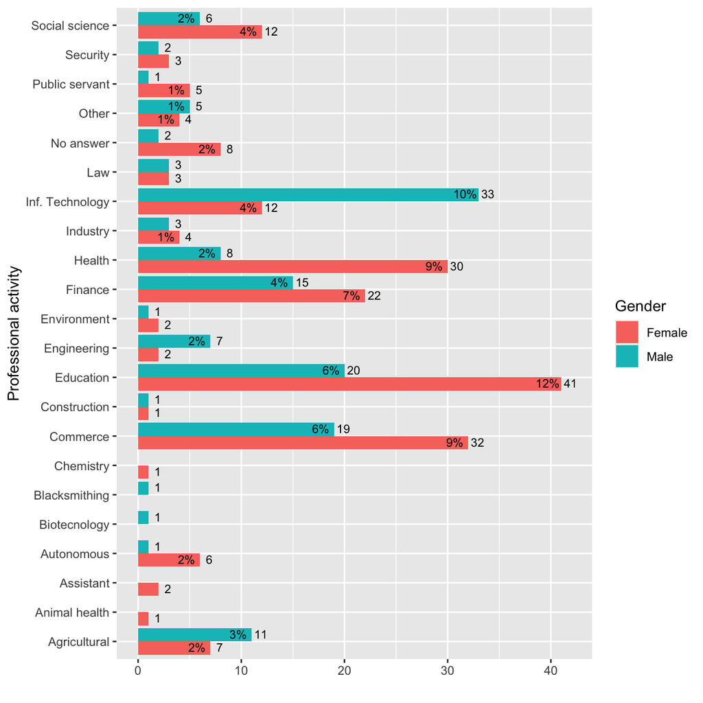

Professional activity of respondents by gender

The following plot shows the professional activity of the respondents by education level. There are a clear pattern of respondents involved in agricultural activities having less years of education, while most doctorate holders work on the education sector.

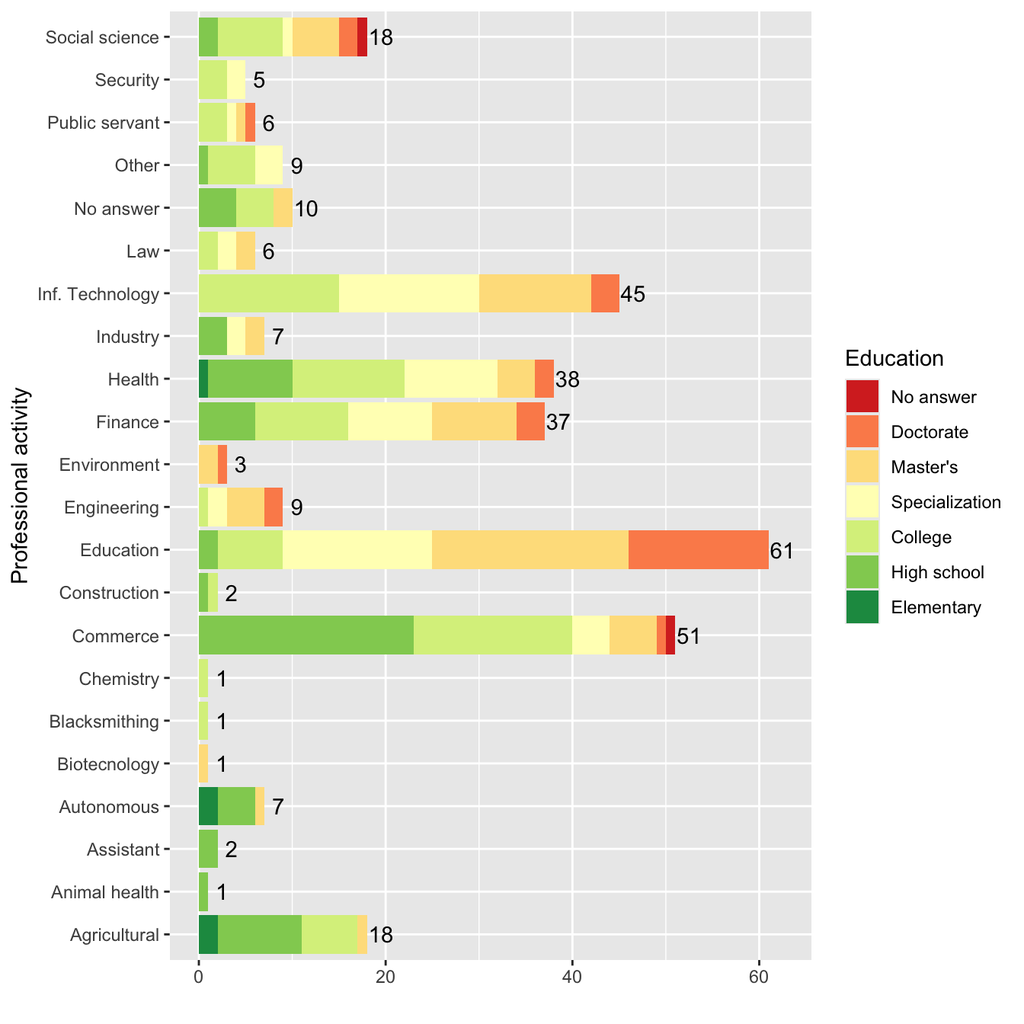

Professional activity of respondents by education level

## Belief in the boomerang effect and education level

The plot below compares the belief in the boomerang effect and the education level of the Facebook users who participated in the survey.

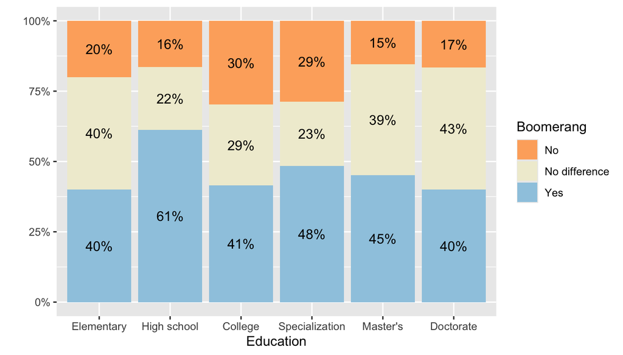

Boomerang and Education

# References

Apuke, Oberiri Destiny, and Bahiyah Omar. 2021a. “Fake news and COVID-19: modelling the predictors of fake news sharing among social media users.” *Telematics and Informatics* 56 (March 2020): 101475. https://doi.org/10.1016/j.tele.2020.101475.

———. 2021b. “User motivation in fake news sharing during the COVID-19 pandemic: an application of the uses and gratification theory.” *Online Information Review* 45 (1): 220–39. https://doi.org/10.1108/OIR-03-2020-0116.

Ardèvol-Abreu, Alberto, Patricia Delponti, and Carmen Rodríguez-Wangüemert. 2020. “Intentional or inadvertent fake news sharing? Fact-checking warnings and users’ interaction with social media content.” *Profesional de La Informacion* 29 (5): 1–13. https://doi.org/10.3145/epi.2020.sep.07.

Atehortua, Nelson A., and Stella Patino. 2021. “COVID-19, a Tale of Two Pandemics: Novel Coronavirus and Fake News Messaging.” *Health Promotion International*. Oxford University Press. https://doi.org/10.1093/heapro/daaa140.

Chua, Alton Y. K., and Snehasish Banerjee. 2018. “Intentions to trust and share online health rumors: An experiment with medical professionals.” *Computers in Human Behavior* 87 (March): 1–9. https://doi.org/10.1016/j.chb.2018.05.021.

De Simoni, Anna, Anjali T. Shah, Olivia Fulton, Jasmine Parkinson, Aziz Sheikh, Pietro Panzarasa, Claudia Pagliari, Neil S. Coulson, and Chris J. Griffiths. 2020. “Superusers’ engagement in asthma online communities: Asynchronous web-based interview study.” *Journal of Medical Internet Research* 22 (6). https://doi.org/10.2196/18185.

Hart, P. Sol, and Erik C. Nisbet. 2012. “Boomerang Effects in Science Communication: How Motivated Reasoning and Identity Cues Amplify Opinion Polarization About Climate Mitigation Policies.” *Communication Research* 39 (6): 701–23. https://doi.org/10.1177/0093650211416646.

Hossain, Mohammad Alamgir, Md Maruf Hossan Chowdhury, Ilias O. Pappas, Bhimaraya Metri, Laurie Hughes, and Yogesh K. Dwivedi. 2023. “Fake News on Facebook and Their Impact on Supply Chain Disruption During COVID-19.” *Annals of Operations Research* 327 (August): 683–711. https://doi.org/10.1007/s10479-022-05124-1.

Islam, A. K. M.Najmul, Samuli Laato, Shamim Talukder, and Erkki Sutinen. 2020. “Misinformation sharing and social media fatigue during COVID-19: An affordance and cognitive load perspective.” *Technological Forecasting and Social Change* 159 (July): 120201. https://doi.org/10.1016/j.techfore.2020.120201.

Khan, M Laeeq, and Ika Karlina Idris. 2019. “Recognise misinformation and verify before sharing : a reasoned action and information literacy perspective.” *Behaviour & Information Technology* 3001. https://doi.org/10.1080/0144929X.2019.1578828.

Kim, Antino, and Alan R. Dennis. 2019. “Says Who? The Effects of Presentation Format and Source Rating on Fake News in Social Media.” *MIS Quarterly: Management Information Systems* 43: 1025–39. https://doi.org/10.25300/MISQ/2019/15188.

Kim, Antino, Patricia L. Moravec, and Alan R. Dennis. 2019. “Combating Fake News on Social Media with Source Ratings: The Effects of User and Expert Reputation Ratings.” *Journal of Management Information Systems* 36: 931–68. https://doi.org/10.1080/07421222.2019.1628921.

Ku, Kelly Y. L., Qiuyi Kong, Yunya Song, Lipeng Deng, Yi Kang, and Aihua Hu. 2019. “What predicts adolescents’ critical thinking about real-life news? The roles of social media news consumption and news media literacy.” *Thinking Skills and Creativity* 33 (May): 100570. https://doi.org/10.1016/j.tsc.2019.05.004.

Mahamad, Tengku Elena Tengku, Nur Syafiqah Ambran, Nur Aziemah Mohd Azman, and Daina Bellido de Luna. 2021. “Insights into social media users’ motives for sharing unverified news.” *SEARCH Journal of Media and Communication Research* 13 (3): 1–18.

Marett, Kent, and K. D. Joshi. 2009. “The decision to share information and rumors: Examining the role of motivation in an online discussion forum.” *Communications of the Association for Information Systems* 24 (1): 47–68. https://doi.org/10.17705/1cais.02404.

Moravec, Patricia L., Antino Kim, and Alan R. Dennis. 2020. “Appealing to Sense and Sensibility: System 1 and System 2 Interventions for Fake News on Social Media.” *Information Systems Research* 31: 987–1006. https://doi.org/10.1287/ISRE.2020.0927.

Moravec, Patricia L., Randall K. Minas, and Alan R. Dennis. 2019. “Fake News on Social Media: People Believe What They Want to Believe When It Makes No Sense at All.” *MIS Quarterly: Management Information Systems* 43: 1343–60. https://doi.org/10.2139/ssrn.3269541.

Pennycook, Gordon, Adam Bear, Evan T. Collins, and David G. Rand. 2020. “The implied truth effect: Attaching warnings to a subset of fake news headlines increases perceived accuracy of headlines without warnings.” *Management Science* 66 (11): 4944–57. https://doi.org/10.1287/mnsc.2019.3478.

Pennycook, Gordon, Ziv Epstein, Mohsen Mosleh, Antonio A. Arechar, Dean Eckles, and David G. Rand. 2021. “Shifting Attention to Accuracy Can Reduce Misinformation Online.” *Nature* 592: 590–95. https://doi.org/10.1038/s41586-021-03344-2.

Pennycook, Gordon, Jonathon McPhetres, Yunhao Zhang, Jackson G. Lu, and David G. Rand. 2020. “Fighting COVID-19 Misinformation on Social Media: Experimental Evidence for a Scalable Accuracy-Nudge Intervention.” *Psychological Science* 31 (7): 770–80. https://doi.org/10.1177/0956797620939054.

Sampat, Brinda, and Sahil Raj. 2022. “Fake or real news? Understanding the gratifications and personality traits of individuals sharing fake news on social media platforms.” *Aslib Journal of Information Management*. https://doi.org/10.1108/AJIM-08-2021-0232.

Shahid, Farhana, Shrirang Mare, and Aditya Vashistha. 2022. “Examining Source Effects on Perceptions of Fake News in Rural India.” *Proceedings of the ACM on Human-Computer Interaction* 6 (CSCW1). https://doi.org/10.1145/3512936.

Talwar, Shalini, Amandeep Dhir, Puneet Kaur, Nida Zafar, and Melfi Alrasheedy. 2019. “Why do people share fake news? Associations between the dark side of social media use and fake news sharing behavior.” *Journal of Retailing and Consumer Services* 51 (May): 72–82. https://doi.org/10.1016/j.jretconser.2019.05.026.

Talwar, Shalini, Amandeep Dhir, Dilraj Singh, Gurnam Singh Virk, and Jari Salo. 2020. “Sharing of Fake News on Social Media: Application of the Honeycomb Framework and the Third-Person Effect Hypothesis.” *Journal of Retailing and Consumer Services* 57 (November). https://doi.org/10.1016/j.jretconser.2020.102197.